# Homework 3

Kai Oda

2/16/2020

In this homework, you will:

1. Import data from an online data repository and understand the metadata
2. Wrangle a large dataset into an appropriate format for a scientific question
3. Visualize data with the goal of comparing means among more than 2 groups
4. Check assumptions for a 1-way ANOVA
5. Conduct a 1-way ANOVA with >2 levels of a factor
6. Add a blocking variable
7. Perform post-hoc testing

As part of your final project, you must find your own dataset to analyze. There are many different repositories from which you can download data, but perhaps one of the easiest for ecological studies is the Environmental Data Initiative repository (www.EDI.org). For this homework, you will download a dataset from EDI that was created by researchers here at UCSB working at the Santa Barbara Channel LTER.

The dataset contains several measurements of many different species across several sites, multiple months and years, and subjected to multiple different treatments. For this homework, we are going to focus our attention on the most abundant order, and we are interested in investigating the mean effect of kelp removal treatment at each site across all time periods.

1. Download the data package from https://portal.edirepository.org/nis/mapbrowse?packageid=knb-lter-sbc.119.2
2. Extract the files from the zip file
3. Copy the csv file and save it in your homework 3 folder
4. Read the metadata available under both tabs on the dataset website

### 1. Data wrangling (30pts)

#### a. Read in the data. What are the dimensions of the dataset? (2pts)

```r
kelp = read.csv("LTE_All_Species_Biomass_at_transect_20181214.csv")
dim(kelp)
```

```
## [1] 165384     24
```

```r
head(kelp)
```

```
##   YEAR MONTH       DATE SITE TRANSECT TREATMENT SP_CODE PERCENT_COVER   DENSITY
## 1 2008     1 2008-01-10 NAPL        3   CONTROL      AB          0.00 -99999.00
## 2 2008     1 2008-01-10 NAPL        3   CONTROL    AHOL     -99999.00      0.00
## 3 2008     1 2008-01-10 NAPL        3   CONTROL      AL          1.25 -99999.00
## 4 2008     1 2008-01-10 NAPL        3   CONTROL     AML     -99999.00      4.55
## 5 2008     1 2008-01-10 NAPL        3   CONTROL    ANDA     -99999.00      0.00
## 6 2008     1 2008-01-10 NAPL        3   CONTROL    ANPA          0.00 -99999.00
##        WM_GM2     DRY_GM2          SFDM         AFDM        SCIENTIFIC_NAME
## 1   0.0000000  0.00000000  0.000000e+00  0.000000000            Abietinaria
## 2   0.0000000  0.00000000 -9.999900e+04  0.000000000     Alloclinus holderi
## 3   0.0597675  0.03687655  2.121746e-02  0.009503032       Astrangia haimei
## 4 240.6465309 73.63783845  5.029512e+01 35.375040039        Patiria miniata
## 5   0.0000000  0.00000000 -9.999900e+04  0.000000000 Anisotremus davidsonii
## 6   0.0000000  0.00000000  0.000000e+00  0.000000000 Anisocladella pacifica
##              COMMON_NAME TAXON_KINGDOM  TAXON_PHYLUM     TAXON_CLASS
## 1 Coarse Sea Fir Hydroid      Animalia      Cnidaria        Hydrozoa
## 2        Island Kelpfish      Animalia      Chordata  Actinopterygii
## 3  Aggregating cup Coral      Animalia      Cnidaria        Anthozoa
## 4               Bat Star      Animalia Echinodermata      Asteroidea
## 5                  Sargo      Animalia      Chordata  Actinopterygii
## 6                 -99999       Plantae    Rhodophyta Florideophyceae
##    TAXON_ORDER   TAXON_FAMILY   TAXON_GENUS  GROUP MOBILITY GROWTH_MORPH
## 1 Leptothecata  Sertulariidae   Abietinaria INVERT  SESSILE   AGGREGATED
## 2  Perciformes   Labrisomidae    Alloclinus   FISH   MOBILE     SOLITARY
## 3 Scleractinia   Rhizangiidae     Astrangia INVERT  SESSILE   AGGREGATED
## 4    Valvatida    Asterinidae       Patiria INVERT   MOBILE     SOLITARY
## 5  Perciformes     Haemulidae   Anisotremus   FISH   MOBILE     SOLITARY
## 6   Ceramiales Delesseriaceae Anisocladella  ALGAE  SESSILE     SOLITARY
```

```r
unique(kelp$SITE)
```

```
## [1] NAPL MOHK AQUE CARP IVEE
## Levels: AQUE CARP IVEE MOHK NAPL
```

There are 165384 rows and 24 columns.

Given the size of this dataset, you must be very careful in ensuring that your knitted file does not print out the whole thing accidentally!

While there are a lot of data in this dataset, we are interested in comparing percent cover of the most abundant order among three different treatments: CONTROL, ANNUAL, and CONTINUAL.

#### b. Look at the metadata for this dataset. What do the different treatments mean? (2pts)

**Control:** Giant kelp (Macrocystis) left in place in a 2000 m^2 plot.  
**Annual removal:** Macrocystis removed annually every winter and allowed to recolonize  
**Continuous removal:** Macrocystis removed from a 200 m^2 area within the 2000 meter plot every time the area is sampled ~4 times/year.

#### c. How many different sites are represented in the dataset, and what are their actual names (you will need to look in the metadata to find this) (3pts)

Five sites were represented in this dataset.  
AQUE = Arroyo Quemado Reef  
CARP = Carpinteria Reef  
MOHK = Mohawk Reef  
NAPL = Naples Reef  
IVEE = Isla Vista Reef

We now have some work to do to get the data in the shape that we want!

#### d. Examine the structure of the data using str(). How are missing values coded in this dataset? (2pts)

Note: You may want to consult the metadata to confirm this

```r
str(kelp)
```

```
## 'data.frame':    165384 obs. of  24 variables:
##  $ YEAR           : int  2008 2008 2008 2008 2008 2008 2008 2008 2008 2008 ...
##  $ MONTH          : int  1 1 1 1 1 1 1 1 1 1 ...
##  $ DATE           : Factor w/ 271 levels "2008-01-10","2008-01-17",..: 1 1 1 1 1 1 1 1 1 1 ...
##  $ SITE           : Factor w/ 5 levels "AQUE","CARP",..: 5 5 5 5 5 5 5 5 5 5 ...
##  $ TRANSECT       : int  3 3 3 3 3 3 3 3 3 3 ...
##  $ TREATMENT      : Factor w/ 5 levels "ANNUAL","CONTINUAL",..: 3 3 3 3 3 3 3 3 3 3 ...
##  $ SP_CODE        : Factor w/ 223 levels "AB","AHOL","AL",..: 1 2 3 4 5 6 7 8 9 10 ...
##  $ PERCENT_COVER  : num  0 -99999 1.25 -99999 -99999 ...
##  $ DENSITY        : num  -99999 0 -99999 4.55 0 ...
##  $ WM_GM2         : num  0 0 0.0598 240.6465 0 ...
##  $ DRY_GM2        : num  0 0 0.0369 73.6378 0 ...
##  $ SFDM           : num  0.00 -1.00e+05 2.12e-02 5.03e+01 -1.00e+05 ...
##  $ AFDM           : num  0 0 0.0095 35.375 0 ...
##  $ SCIENTIFIC_NAME: Factor w/ 217 levels "Abietinaria",..: 1 6 17 147 10 9 11 13 14 76 ...
##  $ COMMON_NAME    : Factor w/ 180 levels "-99999","Acid Weed",..: 43 77 5 10 126 1 4 30 29 124 ...
##  $ TAXON_KINGDOM  : Factor w/ 3 levels "Animalia","Chromista",..: 1 1 1 1 1 3 1 1 1 1 ...
##  $ TAXON_PHYLUM   : Factor w/ 13 levels "Annelida","Arthropoda",..: 6 5 6 7 5 12 6 9 9 5 ...
##  $ TAXON_CLASS    : Factor w/ 25 levels "-99999","Actinopterygii",..: 17 2 3 5 2 12 3 13 13 4 ...
##  $ TAXON_ORDER    : Factor w/ 69 levels "-99999","Actiniaria",..: 37 49 56 69 49 11 2 7 7 6 ...
##  $ TAXON_FAMILY   : Factor w/ 129 levels "-99999","Actiniidae",..: 110 66 95 9 55 39 2 7 7 90 ...
##  $ TAXON_GENUS    : Factor w/ 174 levels "-99999","Abietinaria",..: 2 7 14 124 10 9 11 12 12 59 ...
##  $ GROUP          : Factor w/ 3 levels "ALGAE","FISH",..: 3 2 3 3 2 1 3 3 3 3 ...
##  $ MOBILITY       : Factor w/ 2 levels "MOBILE","SESSILE": 2 1 2 1 1 2 2 1 1 2 ...
##  $ GROWTH_MORPH   : Factor w/ 2 levels "AGGREGATED","SOLITARY": 1 2 1 2 2 2 1 2 2 1 ...
```

Values that are “not recorded or available” are recorded as **-99999.**

*We now are going to thin our dataset to exclude these missing values for our response variable of interest, PERCENT_COVER.*

#### e. Create a new dataframe (called kelp2) that excludes any row that contains a missing value (as coded above).

Hint: One way to alter dataframes combines indices and the which() function. For example, let’s say I have a dataframe, d:

```r
d = data.frame(ID=seq(1,5),value=sample(1:8,5))
d
```

```
##   ID value
## 1  1     2
## 2  2     3
## 3  3     8
## 4  4     6
## 5  5     1
```

And I would like to remove any row that has an ID greater than 4. I can write:

```r
d2 = d[-which(d$ID>4),]
d2
```

```
##   ID value
## 1  1     2
## 2  2     3
## 3  3     8
## 4  4     6
```

#### Now apply this logic to the kelp dataset. What are the dimensions of the new dataset? (4pts)

Note: you should use head() to examine the dataset rather than printing it out (otherwise you may be printing output endlessly!)

```r
kelp2 = kelp[-which(kelp$PERCENT_COVER<0),]
dim(kelp2)
```

```
## [1] 74052    24
```

**There are now 74052 rows and 24 columns.**

We have also already decided that we are going to restrict our analyses to only compare CONTROL, ANNUAL, and CONTINUAL removal.

#### f. Remove any row that has a treatment not equal to CONTROL, ANNUAL, or CONTINUAL.

Hint: You can use a really handy shortcut, “%in%” to keep or remove multiple values in one go. Let’s go back to our boring old dataframe again. To remove any ID equal to either a 2 or a 3, I can write:

```r
d[-which(d$ID %in% c(2,3)),]
```

```
##   ID value
## 1  1     2
## 4  4     6
## 5  5     1
```

```r
# I used the minus sign to tell R to subtract any row in the d$ID column that is either 2 or 3. Using %in% with no minus sign returns rows with IDs either 2 or 3.
```

#### Now apply this logic to the kelp dataset to remove any treatment that is not CONTROL, ANNUAL, or CONTINUAL and call it kelp3. How many rows are left? (4pts)

```r
kelp3 = kelp2[which(kelp2$TREATMENT %in% c("CONTROL", "ANNUAL", "CONTINUAL")),]
dim(kelp3)
```

```
## [1] 68112    24
```

There are 68112 rows and the same 24 columns left.

We still have a LOT of datapoints – too many to make really meaningful plots without summarizing in some way.

We are now going to simplify our data to show the percent cover of each taxonomic order in the data. To do this, we need to take the percent cover for each species within each order and add them up.

The dplyr package has some great functions to help you to group by different variables and compute averages, sums, differences, and more.

#### g. Compute the total percent cover of each order by adding the percent cover of constituent species.

Note: Here we are assuming that cover is mutually exclusive among species.

Hint: Let’s make a new boring dataframe:

```r
# Code to make a new df
d = data.frame(ID=seq(1,20),Value=rnorm(20),Factor1=c(rep("A",10),rep("B",10)), Factor2=c(rep("RED",5),rep("YELLOW",5),rep("ORANGE",5),rep("PURPLE",5)))
head(d)
```

```
##   ID       Value Factor1 Factor2
## 1  1  1.54739581       A     RED
## 2  2  1.41766399       A     RED
## 3  3  0.01591965       A     RED
## 4  4 -0.63254554       A     RED
## 5  5  1.58435648       A     RED
## 6  6 -2.20797603       A  YELLOW
```

You can use “pipes” “%>%” to string together multiple functions. In the example below, I take my dataframe, group it by the factors I want to sum across, and then summarize the column of interest (Value) by computing the sum.

```r
d %>% group_by(Factor1, Factor2) %>% summarize_at(vars(Value),funs(sum))
```

```
## # A tibble: 4 x 3
## # Groups:   Factor1 [2]
##   Factor1 Factor2  Value
##   <fct>   <fct>    <dbl>
## 1 A       RED      3.93
## 2 A       YELLOW  -0.981
## 3 B       ORANGE   3.29
## 4 B       PURPLE  -1.34
```

```r
# The result is the sum of all rows for each of the four groups
```

#### Now apply this logic to the kelp data and name it kelp4. Use SITE, TRANSECT, TREATMENT, TAXON_ORDER, MONTH, and YEAR as grouping variables. What are the dimensions of kelp4? (5pts)

```r
kelp4 = kelp3 %>% group_by(SITE, TRANSECT, TREATMENT, TAXON_ORDER, MONTH, YEAR) %>%
  summarize_at(vars(PERCENT_COVER), funs(sum))
head(kelp4)
```

```
## # A tibble: 6 x 7
## # Groups:   SITE, TRANSECT, TREATMENT, TAXON_ORDER, MONTH [2]
##   SITE  TRANSECT TREATMENT TAXON_ORDER MONTH  YEAR PERCENT_COVER
##   <fct>    <int> <fct>     <fct>       <int> <int>         <dbl>
## 1 AQUE         4 CONTROL   -99999          1  2008         16.2
## 2 AQUE         4 CONTROL   -99999          1  2009         12.5
## 3 AQUE         4 CONTROL   -99999          1  2011          7.5
## 4 AQUE         4 CONTROL   -99999          2  2010          3.75
## 5 AQUE         4 CONTROL   -99999          2  2012          0
## 6 AQUE         4 CONTROL   -99999          2  2013          1.25
```

```r
dim(kelp4)
```

```
## [1] 26144     7
```

```r
# kelp4 = kelp4[-which(kelp4$TAXON_ORDER %in% c(-99999)),]
# dim(kelp4)
```

When I initially ran the code there were **26144 rows and 7 columns** BUT there was a taxon order with -99999. I kept this taxon because I did not want to delete the data but the commented lines will remove this taxon. Removing the -99999 taxon reduced the number of rows to 25456.

#### Slowly but surely, we are simplifying these data! Check out the last few lines of kelp4 using the tail() function.

```r
tail(kelp4)
```

```
## # A tibble: 6 x 7
## # Groups:   SITE, TRANSECT, TREATMENT, TAXON_ORDER, MONTH [1]
##   SITE  TRANSECT TREATMENT TAXON_ORDER MONTH  YEAR PERCENT_COVER
##   <fct>    <int> <fct>     <fct>       <int> <int>         <dbl>
## 1 NAPL        10 CONTINUAL Ulvales        11  2010             0
## 2 NAPL        10 CONTINUAL Ulvales        11  2011             0
## 3 NAPL        10 CONTINUAL Ulvales        11  2012             0
## 4 NAPL        10 CONTINUAL Ulvales        11  2013             0
## 5 NAPL        10 CONTINUAL Ulvales        11  2014             0
## 6 NAPL        10 CONTINUAL Ulvales        11  2015             0
```

#### h. Why should we take the average percent cover (across transect and time period for each order) if we are only interested in comparing the treatments (using sites as replicates)? (3pts)

The average percent cover is a simple way to visualize the effect of treatment (continual, annual, control) and taxon order on percent cover. Additionally, representing each data point assumes that they are all independent. However, there may be similarities across transects (similar to how rump stripes on the same zebra may not be independent). If we did not take the mean percent cover we would be at risk of pseudoreplication as some points are likely to be non-independent.

There are ways to incorporate these details in statistical models, but for now we will simply average across them using a similar method to how we added percent cover.

#### i. Calculate the average PERCENT_COVER for each order at each site and treatment, grouping by TREATMENT, SITE, and TAXON_ORDER. (5pts)

```r
kelp5 = kelp4 %>% group_by(TREATMENT, SITE, TAXON_ORDER) %>%
  summarize_at(vars(PERCENT_COVER), funs(mean))
dim(kelp5)
```

```
## [1] 532   4
```

Your final kelp5 dataset should have 532 rows. If it does not, recheck your work!

### 2. Visualizing and zooming in on the most abundant order. (18pts)

#### a. Create an informative plot of the data. Explain what you are showing. (5pts)

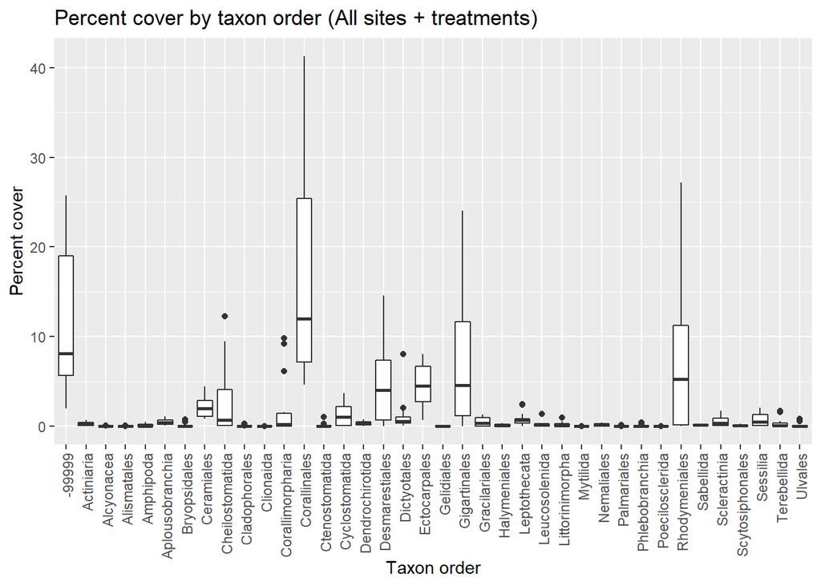

```r
ggplot(kelp5, aes(x=TAXON_ORDER, y=PERCENT_COVER))+
  geom_boxplot()+
  ggtitle("Percent cover by taxon order (All sites + treatments)")+
  theme(axis.text.x = element_text(angle=90, hjust=1, vjust=0.6))+
  labs(x="Taxon order", y="Percent cover")
```

```r
  theme(plot.title = element_text(hjust=0.5))
```

[output not shown]

This is a simple plot that shows the average percent cover of different taxon orders. It appears that Corallinales has the highest median percent cover. There are quite a few outliers across the different orders so we should check normality and variance before we perform an anova.

#### b. Which order has the highest percent cover on average? (5pts)

```r
kelpHigh = kelp5 %>% group_by(TAXON_ORDER) %>%
  summarize_at(vars(PERCENT_COVER), funs(sum))
kelpHigh_sorted <- kelpHigh[with(kelpHigh, order(-PERCENT_COVER)),]
head(kelpHigh_sorted)
```

```
## # A tibble: 6 x 2
##   TAXON_ORDER    PERCENT_COVER
##   <fct>                  <dbl>
## 1 Corallinales           234.
## 2 -99999                 162.
## 3 Rhodymeniales          110.
## 4 Gigartinales           106.
## 5 Desmarestiales          68.2
## 6 Ectocarpales            62.3
```

The order **Corallinales** has the highest percent cover on average (234.1% over five sites and three treatments)

#### c. Trim the dataset to only include the most abundant order and save it as a new dataframe. (3pts)

```r
d[-which(d$ID %in% c(2,3)),]
```

```
##    ID      Value Factor1 Factor2
## 1   1  1.5473958       A     RED
## 4   4 -0.6325455       A     RED
## 5   5  1.5843565       A     RED
## 6   6 -2.2079760       A  YELLOW
## 7   7  0.2171794       A  YELLOW
## 8   8  0.1462712       A  YELLOW
## 9   9 -0.4286475       A  YELLOW
## 10 10  1.2922609       A  YELLOW
## 11 11 -0.1757177       B  ORANGE
## 12 12  0.5358027       B  ORANGE
## 13 13  0.7039240       B  ORANGE
## 14 14  1.2119341       B  ORANGE
## 15 15  1.0112110       B  ORANGE
## 16 16 -1.1568632       B  PURPLE
## 17 17 -0.2346070       B  PURPLE
## 18 18  0.7422105       B  PURPLE
## 19 19 -0.1915132       B  PURPLE
## 20 20 -0.4966838       B  PURPLE
```

```r
kelp_order = kelp5[which(kelp5$TAXON_ORDER %in% c("Corallinales")),]
head(kelp_order)
```

```
## # A tibble: 6 x 4
## # Groups:   TREATMENT, SITE [6]
##   TREATMENT SITE  TAXON_ORDER  PERCENT_COVER
##   <fct>     <fct> <fct>                <dbl>
## 1 ANNUAL    AQUE  Corallinales          5.87
## 2 ANNUAL    CARP  Corallinales         14.4
## 3 ANNUAL    IVEE  Corallinales          6.88
## 4 ANNUAL    MOHK  Corallinales          7.29
## 5 ANNUAL    NAPL  Corallinales         25.5
## 6 CONTINUAL AQUE  Corallinales         11.8
```

#### d. Create a plot that compares percent cover across the different treatments for this group. (5pts)

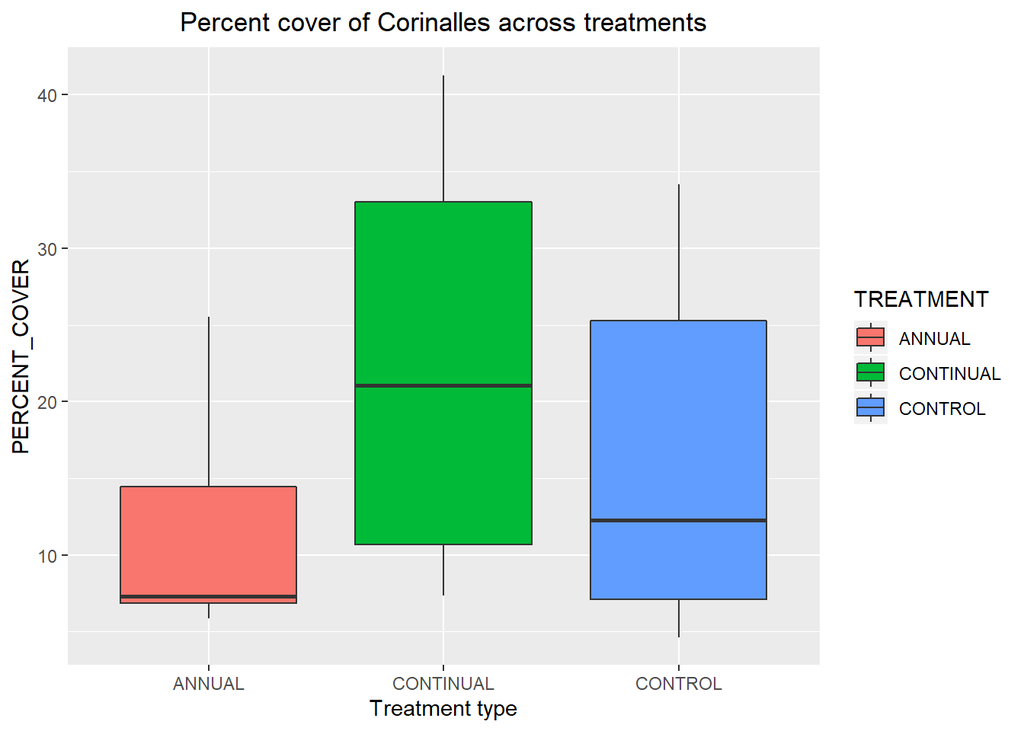

```r
ggplot(kelp_order, aes(x=TREATMENT, y=PERCENT_COVER, fill=TREATMENT))+
  geom_boxplot()+
  labs(x="Treatment type")+
  ggtitle("Percent cover of Corinalles across treatments")+
  theme(plot.title=element_text(hjust=0.5))
```

FINALLY, we are ready to conduct a one-way ANOVA!

### 3. Implementing a 1-way ANOVA (30pts)

#### a. What are your null and alternative hypotheses for a 1-way ANOVA of percent cover among different treatments? (4pts)

**Null:** The mean percent cover for all groups (annual, continual and control) will be the same.  
**Alternative:** The mean percent cover for at least one group will be different from the others.

#### b. Check for normality and equality of variance. Are your assumptions met? (4pts)

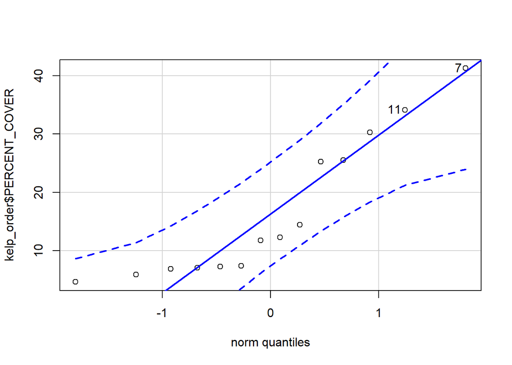

```
## [1]  7 11
```

```r
car::qqPlot(kelp_order$PERCENT_COVER)
```

```r
kelp_order %>% group_by(TREATMENT) %>% summarize_at(vars(PERCENT_COVER), funs(statistic=shapiro.test(.)$statistic, p.value=shapiro.test(.)$p.value))
```

```
## # A tibble: 3 x 3
##   TREATMENT statistic p.value
##   <fct>         <dbl>   <dbl>
## 1 ANNUAL        0.807  0.0918
## 2 CONTINUAL     0.919  0.534
## 3 CONTROL       0.907  0.447
```

```r
leveneTest(kelp_order$PERCENT_COVER ~ kelp_order$TREATMENT)
```

```
## Levene's Test for Homogeneity of Variance (center = median)
##       Df F value Pr(>F)
## group  2  1.2196 0.3324
##       11
```

**Normality:** A qqPlot of the percent cover data appears to show all data points within the expected confidence interval. The shapiro test shows p values that are all greater than 0.05, which means we cannot reject the null hypothesis that the data is normally distributed.  
**Variance:** The Levene test returns a p value greater than 0.05, which means we cannot reject the null hypothesis that the variances are equal. Therefore, we meet both the normal and variance requirements for the ANOVA test.

### Hand-calculating an ANOVA

#### c. Calculate the sum of squares for the groups (consider sites as replicates for now). (8pts)

```r
# You might find it easiest to subset the data into a group for each treatment:
ANNUAL = subset(kelp_order, kelp_order$TREATMENT == "ANNUAL")
CONTINUAL = subset(kelp_order, kelp_order$TREATMENT == "CONTINUAL")
CONTROL = subset(kelp_order, kelp_order$TREATMENT == "CONTROL")

# Find the mean percent cover for each group
A= mean(ANNUAL$PERCENT_COVER)
B= mean(CONTINUAL$PERCENT_COVER)
C= mean(CONTROL$PERCENT_COVER)

# Find the overall mean
G= mean(kelp_order$PERCENT_COVER)

# Find the sample size for each group
A_df <- length(ANNUAL$PERCENT_COVER) - 1
B_df <- length(CONTINUAL$PERCENT_COVER) - 1
C_df <- length(CONTROL$PERCENT_COVER) - 1

# Compute sum of squares
SSgroup = 5*(A-G)^2 + 4*(B-G)^2 + 5*(C-G)^2
```

My SSgroup is 253.6875739.

#### d. Now calculate the residual SS (within group error) (5pts)

```r
### You can easily do this using the var() or sd() functions (check your notes with the squirrel body temp example)

SSerror = (A_df*var(ANNUAL$PERCENT_COVER)) + (B_df*var(CONTINUAL$PERCENT_COVER)) + (C_df*(var(CONTROL$PERCENT_COVER)))
```

My SSerror is 1666.8328586.

#### e. Now compute the F-stat and find F-star. (4pts)

```r
MSgroup = SSgroup / 2
MSerror = SSerror / (A_df + B_df + C_df + 3)


Fstat = MSgroup/MSerror
Fstar = qf(1-0.05, 2, 6)

kelp_anova <- aov(PERCENT_COVER ~ TREATMENT, data=kelp_order)
summary(kelp_anova)
```

```
##             Df Sum Sq Mean Sq F value Pr(>F)
## TREATMENT    2  253.7   126.8   0.837  0.459
## Residuals   11 1666.8   151.5
```

#### f. Do you reject or fail to reject the null hypothesis of equal between- and within-group variances? (2pts)

Since the Fstat is less extreme than the calculated Fstar we fail to reject the null hypothesis that the between and within group variances are significantly different. Additionally, we also cannot reject the null hypothesis that the means of all the groups are the same. This is confirmed by running the actual ANOVA, which returns a p value greater than 0.05.

#### g. Implement the ANOVA using the aov() function and print the summary. Does it match your calculations? (4pts)

```r
mod1 = aov(PERCENT_COVER ~ TREATMENT, data=kelp_order)
summary(mod1)
```

```
##             Df Sum Sq Mean Sq F value Pr(>F)
## TREATMENT    2  253.7   126.8   0.837  0.459
## Residuals   11 1666.8   151.5
```

Given that each treatment was conducted at eact of five sites, we may want to include site as a block.

### 4. Add a blocking effect. (15pts)

#### a. Include site as a second factor in your analysis using aov() and lm(). Print the summary outputs. (4pts)

```r
#aov method
mod2 = aov(PERCENT_COVER ~ TREATMENT+SITE,data=kelp_order)
summary(mod2)
```

```
##             Df Sum Sq Mean Sq F value Pr(>F)
## TREATMENT    2  253.7   126.8   3.551 0.0862 .
## SITE         4 1416.8   354.2   9.914 0.0052 **
## Residuals    7  250.1    35.7
## ---
## Signif. codes:  0 '***' 0.001 '**' 0.01 '*' 0.05 '.' 0.1 ' ' 1
```

```r
#lm method
lm_mod2 <- lm(PERCENT_COVER ~ TREATMENT+SITE, data=kelp_order)
summary(lm_mod2)
```

```
##
## Call:
## lm(formula = PERCENT_COVER ~ TREATMENT + SITE, data = kelp_order)
##
## Residuals:
##      Min       1Q   Median       3Q      Max
## -10.7853  -1.6606  -0.7356   2.9936   6.5561
##
## Coefficients:
##                    Estimate Std. Error t value Pr(>|t|)
## (Intercept)           3.518      4.119   0.854  0.42142
## TREATMENTCONTINUAL    9.492      4.119   2.304  0.05464 .
## TREATMENTCONTROL      4.683      3.780   1.239  0.25533
## SITECARP             21.717      4.880   4.450  0.00297 **
## SITEIVEE              3.711      5.591   0.664  0.52809
## SITEMOHK             -1.810      4.880  -0.371  0.72175
## SITENAPL             18.775      4.880   3.847  0.00632 **
## ---
## Signif. codes:  0 '***' 0.001 '**' 0.01 '*' 0.05 '.' 0.1 ' ' 1
##
## Residual standard error: 5.977 on 7 degrees of freedom
## Multiple R-squared:  0.8698, Adjusted R-squared:  0.7582
## F-statistic: 7.793 on 6 and 7 DF,  p-value: 0.007969
```

```r
anova(lm_mod2)
```

```
## Analysis of Variance Table
##
## Response: PERCENT_COVER
##           Df  Sum Sq Mean Sq F value  Pr(>F)
## TREATMENT  2  253.69  126.84  3.5505 0.08619 .
## SITE       4 1416.75  354.19  9.9142 0.00520 **
## Residuals  7  250.08   35.73
## ---
## Signif. codes:  0 '***' 0.001 '**' 0.01 '*' 0.05 '.' 0.1 ' ' 1
```

#### b. Which treatment has the highest percent cover? Which site has the highest percent cover? (4pts)

The **continual** removal treatment has the highest percent cover. **Carpinteria** is the site with the highest percent cover.

### Post Hoc Comparisons

Let’s say we were interested in only comparing percent cover among the different sites.

#### c. Fit a 1-way ANOVA using only SITE as the grouping factor and print the summary. You can use either aov() or lm(). (3pts)

```r
mod3 = aov(PERCENT_COVER ~ SITE, data=kelp_order)
summary(mod3)
```

```
##             Df Sum Sq Mean Sq F value  Pr(>F)
## SITE         4 1479.3   369.8   7.543 0.00597 **
## Residuals    9  441.3    49.0
## ---
## Signif. codes:  0 '***' 0.001 '**' 0.01 '*' 0.05 '.' 0.1 ' ' 1
```

#### d. Conduct a post hoc test on the model using the TukeyHSD function. Which sites differ from which? (5pts)

```r
TukeyHSD(mod3)
```

```
##   Tukey multiple comparisons of means
##     95% family-wise confidence level
##
## Fit: aov(formula = PERCENT_COVER ~ SITE, data = kelp_order)
##
## $SITE
##                 diff         lwr       upr     p adj
## CARP-AQUE  21.716860   2.4923285 40.941391 0.0265142
## IVEE-AQUE   1.327548 -20.1661313 22.821228 0.9994995
## MOHK-AQUE  -1.809626 -21.0341578 17.414905 0.9974001
## NAPL-AQUE  18.774587  -0.4499443 37.999118 0.0561036
## IVEE-CARP -20.389312 -41.8829911  1.104368 0.0643860
## MOHK-CARP -23.526486 -42.7510176 -4.301955 0.0168559
## NAPL-CARP  -2.942273 -22.1668041 16.282258 0.9836681
## MOHK-IVEE  -3.137175 -24.6308540 18.356505 0.9862825
## NAPL-IVEE  17.447039  -4.0466405 38.940718 0.1256580
## NAPL-MOHK  20.584213   1.3596822 39.808745 0.0353348
```

```r
post_hoc <- glht(mod3, linfct = mcp(SITE="Tukey"))
summary(post_hoc)
```

```
##
##   Simultaneous Tests for General Linear Hypotheses
##
## Multiple Comparisons of Means: Tukey Contrasts
##
##
## Fit: aov(formula = PERCENT_COVER ~ SITE, data = kelp_order)
##
## Linear Hypotheses:
##                  Estimate Std. Error t value Pr(>|t|)
## CARP - AQUE == 0   21.717      5.717   3.799   0.0264 *
## IVEE - AQUE == 0    1.328      6.392   0.208   0.9995
## MOHK - AQUE == 0   -1.810      5.717  -0.317   0.9974
## NAPL - AQUE == 0   18.775      5.717   3.284   0.0560 .
## IVEE - CARP == 0  -20.389      6.392  -3.190   0.0641 .
## MOHK - CARP == 0  -23.526      5.717  -4.115   0.0167 *
## NAPL - CARP == 0   -2.942      5.717  -0.515   0.9836
## MOHK - IVEE == 0   -3.137      6.392  -0.491   0.9862
## NAPL - IVEE == 0   17.447      6.392   2.730   0.1253
## NAPL - MOHK == 0   20.584      5.717   3.600   0.0352 *
## ---
## Signif. codes:  0 '***' 0.001 '**' 0.01 '*' 0.05 '.' 0.1 ' ' 1
## (Adjusted p values reported -- single-step method)
```

CARP differs from AQUE (p value less than 0.05). CARP has significantly more Corallinales than AQUE.  
CARP differs significantly from MOHK. Once again, CARP has significantly more Corallinales than MOHK.  
NAPLES differs signfiicantly from MOHK. NAPLEs has significantly more Corallinales than MOHK.

#### e. Why might we care about the effect of kelp removal on your chosen taxonomic order? (3pts)

Giant kelp may be sensitive to the effects of climate change. Increasing wave action (brought on by more extreme weather patters) and ocean heating could decrease the prevalence of giant kelp. In that case, it is important to know how Corallinales would be affected by the kelp’s dissapearance. Would it increase, decrease or remain unaffected?

#### f. What additional factor(s) would you want to investigate with this dataset? (2pts)

Investigating the effect of kelp removal on other taxonomic orders might reveal interesting trends. Additionally, the sampling time varies when looking back at the “month” column of the unfiltered database. It is possible that percent cover of specific orders are influenced on an annual cycle (especially in the annual removal treatment). Therefore, it might be interesting to look at the percent cover of a particular species by month, or to only look at the percent cover of a particular species at the same month every year (as opposed to averaging the percent cover from all months into one year).